# Scraping and Cleaning Economic Data

Inter-American Development Bank Workshop

Diego A. Guerrero

2025-11-23

# Learning Objectives

# Scraping Economic Data

## Accessing data in the web

### Application Programming Interfaces (APIs)

- **Definition:** Structured gateways allowing to query databases and retrieve data automatically.
- **Examples:**
  - [FRED API](https://fred.stlouisfed.org/docs/api/fred/)
  - [World Bank Data API](https://datahelpdesk.worldbank.org/knowledgebase/topics/125589)
  - [IMF API](https://datahelp.imf.org/)

There tends to be thorough documentation on how to access the API. A Key is typically required.

### FRED API

Some data sources have python libraries. `fredapi` is a good example and it is installed with `conda install fredapi`

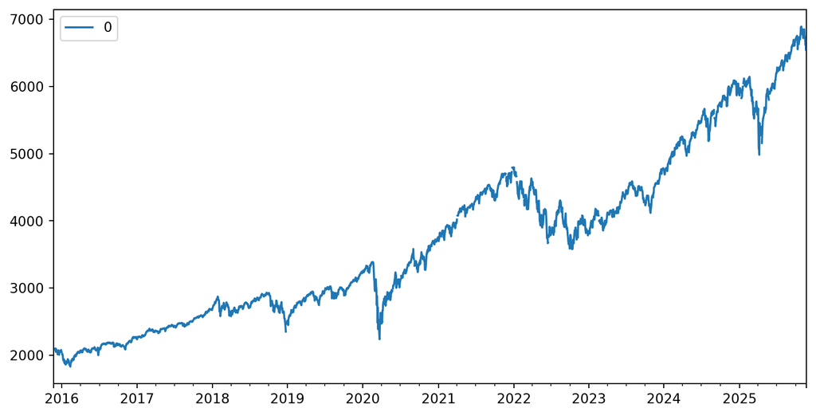

```python
import pandas as pd
import matplotlib as plt
from fredapi import Fred
fred = Fred(api_key='6082258bcc5fa73a032d9d60c890f744')
data = fred.get_series('SP500')
data = pd.DataFrame(data)
data.plot()
```

### Multiple queries

```python
import requests
import pandas as pd
series = ["SP500", "DJIA", "NASDAQCOM"]
api_key = "6082258bcc5fa73a032d9d60c890f744"

df = pd.DataFrame()
for serie in series :

    url = f"https://api.stlouisfed.org/fred/series/observations?series_id={serie}&api_key={api_key}&file_type=json"

    response = requests.get(url)
    response = response.json()

    dfi = pd.DataFrame(response['observations'])
    dfi = dfi[['value', 'date']]

    dfi.set_index('date', inplace=True)
    dfi.index = pd.to_datetime(dfi.index)

    dfi.rename(columns = { "value" : f"fred_{serie}" }, inplace=True)
    dfi[f"fred_{serie}"] = dfi[f"fred_{serie}"].apply(pd.to_numeric, errors='coerce')

    df = df.merge(dfi, left_index=True, right_index=True, how='outer')
    df = pd.DataFrame(df.resample("D").mean())
    df.sort_index(inplace=True)

df.tail(5)
```

| date | fred_SP500 | fred_DJIA | fred_NASDAQCOM |
| --- | --- | --- | --- |
| 2025-11-17 | 6672.41 | 46590.24 | 22708.07 |
| 2025-11-18 | 6617.32 | 46091.74 | 22432.85 |
| 2025-11-19 | 6642.16 | 46138.77 | 22564.23 |
| 2025-11-20 | 6538.76 | 45752.26 | 22078.05 |
| 2025-11-21 | 6602.99 | 46245.41 | 22273.08 |

### Direct web requests

When no API is available, data can still be retrieved from static web resources. Files are downloaded using HTTP requests.

Formats: `.csv`, `.xlsx`, `.txt`, `.zip`, `.pdf`

`pandas` can sometimes manage this directly but sometimes you need a `request`

```python
#| echo: false
import pandas as pd
url = "https://example.com/data.csv"
df = pd.read_csv(url)
```

```python
#| echo: false
import requests
import pandas as pd
from io import StringIO

# Step 1: Download the CSV file via HTTP request
url = "https://example.com/data.csv"
response = requests.get(url)

# Step 2: Check that the request was successful
if response.status_code == 200:
    # Step 3: Convert content into DataFrame
    csv_data = StringIO(response.text)
    df = pd.read_csv(csv_data)

    print("Download complete. Data preview:")
else:
    print(f"Failed to download file. Status code: {response.status_code}")
```

### Advanced Requests and Headers

Most websites block requests that do not come from explorers. We can use request options to send header information.

```python
hdr = {'User-Agent': 'Mozilla/5.0 (Windows NT 10.0; Win64; x64) AppleWebKit/537.36 (KHTML, like Gecko) Chrome/58.0.3029.110 Safari/537'}

url = "https://www.bahamas.gov.bs"
r = requests.get(url=url, verify=None, headers=hdr).content
```

`headers`: the website is notified that the request is made through Mozilla/Chrome

`verify`: SSL certificate verification

### Request output with Beautiful Soup

Most websites are developed in HTML. Beautiful Soup is a web parser that readers HTML tags.

```python
hdr = {'User-Agent': 'Mozilla/5.0 (Windows NT 10.0; Win64; x64) AppleWebKit/537.36 (KHTML, like Gecko) Chrome/58.0.3029.110 Safari/537'}

url = "https://www.bahamas.gov.bs"
r = requests.get(url=url, verify=None, headers=hdr).content
soup = BeautifulSoup(r)
```

The website is now stored on the variable `soup`.

We can list all html `<a>` tags (links) using:

```python
links = [ link.get("href") for link in soup('a') if link.get("href") is not None ]
```

### Opening the file

We can use the trick above to list all `.csv` or `.xlsx` files in a website:

```python
hdr = {'User-Agent': 'Mozilla/5.0 (Windows NT 10.0; Win64; x64) AppleWebKit/537.36 (KHTML, like Gecko) Chrome/58.0.3029.110 Safari/537'}

url = "https://www.bahamas.gov.bs"
r = requests.get(url=url, verify=None, headers=hdr).content
soup = BeautifulSoup(r)
links = [ link.get("href") for link in soup('a') if link.get("href") is not None and "csv" in link.get('href') ]
```

The list `links` will have the URL of all csv files. Now we can open the file:

```python
get = links[0]
response = requests.get(get, verify=None, headers=hdr)
df = pd.read_csv(response.content)
```

### Downloading

Suppose we have stored a file’s url in the variable “get”. Many times we can open this file directly:

```python
response = requests.get(get, stream=True)
```

Sometimes, however, we need to download the file:

```python
response = requests.get( get , verify=False, timeout=300, headers=hdr)
file_name = "MyFile.pdf"
file_name = f"{folder_spec}/{file_name}"
with open( file_name , 'wb') as file: file.write(response.content)
print(f"Downloaded")
```

## Managing pdfs

pdfs are the most complicated data structures to clean.

`PyPDF2` reads the pdf and eases finding the right page.

```python
import tabula, camelot, PyPDF2

def extract_page_text(pdf_path):
  '''
  extract_page_text function opens a pdf an reads all the text. It is used to search specific pages
  '''
  def extract_page_text(pdf_path):
    with open(pdf_path, 'rb') as pdf_file:
        reader = PyPDF2.PdfReader(pdf_file)
        page_texts = [page.extract_text() for page in reader.pages]
    return page_texts
```

`camelot` and `tabula` specialize in managing pdf Tables.

### The pdf process

```python
import tabula, camelot, PyPDF2, requests
import pandas as pd

response = requests.get(get, stream=True)

file_name = f"{folder_spec}/gdp_file.pdf"
with open( file_name , "wb") as pdf_file:
    for chunk in response.iter_content(chunk_size=8192):
        if chunk:
            pdf_file.write(chunk)

# Find the page number
page_texts = extract_page_text(file_name)
table_2_pages = [i + 1 for i, text in enumerate(page_texts) if "TABLE 2" in text ]

# Iterate over all pages with the word TABLE 2 and extract them as tables inside a list "tables"
if table_2_pages :
    tables = []
    for page in table_2_pages:
        page_tables = camelot.read_pdf(file_name, pages=str(page))
        tables.extend(page_tables)

  df0 = pd.DataFrame()
  for x in range(0,len(tables)) :
      # Open the Table
      df = tables[x].df
      # Cleaning

      df0 = pd.concat([df0, df], axis=0)
```

### The pdf process: step-by-step

[figure not shown]

### Opening the file

```python
import camelot, PyPDF2
import pandas as pd

def extract_page_text(pdf_path):
  with open(pdf_path, 'rb') as pdf_file:
      reader = PyPDF2.PdfReader(pdf_file)
      page_texts = [page.extract_text() for page in reader.pages]
  return page_texts

file_name = f"session_2_files/gdp_file.pdf"

# Find the page number
page_texts = extract_page_text(file_name)
table_2_pages = [i + 1 for i, text in enumerate(page_texts) if "TABLE 2" in text ]
print(table_2_pages)
```

```
[6, 7, 8]
```

# Data Cleaning

## Working dataset

**National Budget** 10 Year Monthly Data (xlsx)

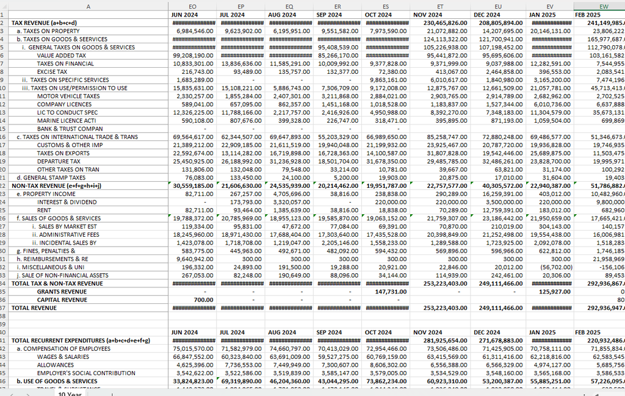

### Open the file with pandas

```python
import pandas as pd

file = "session_2_files/MonthlyData.xlsx"
df = pd.read_excel(file)
df
```

|  | Unnamed: 0 | JUL 2012 | AUG 2012 | SEP 2012 | OCT 2012 | NOV 2012 | DEC 2012 | JAN 2013 | FEB 2013 | MAR 2013 | ... | MAY 2024 | JUN 2024 | JUL 2024 | AUG 2024 | SEP 2024 | OCT 2024 | NOV 2024 | DEC 2024 | JAN 2025 | FEB 2025 |
| --- | --- | --- | --- | --- | --- | --- | --- | --- | --- | --- | --- | --- | --- | --- | --- | --- | --- | --- | --- | --- | --- |
| 0 | TAX REVENUE (a+b+c+d) | 93040348 | 86483176 | 78642733 | 82883677 | 92179630 | 133238356 | 114824826 | 96878244 | 104590342 | ... | 241613741 | 204402400 | 255231585 | 193503688 | 167475359 | 236023998 | 230465826 | 208805894 | 278995125 | 241149985 |
| 1 | a. TAXES ON PROPERTY | 5365152 | 3671873 | 4019217 | 4465873 | 14157876 | 30151541 | 11907058 | 5451162 | 6462140 | ... | 21913491 | 6984546 | 9623902 | 6195951 | 9551582 | 7973590 | 21072882 | 14207695 | 20146131 | 23806222 |
| 2 | b. TAXES ON GOODS & SEERVICES | 37405548 | 39184491 | 35059983 | 36258228 | 36706457 | 39313639 | 58119469 | 51401840 | 55054774 | ... | 141071438 | 127777154 | 183129726 | 117635744 | 102715248 | 161040855 | 124113322 | 121700941 | 189330813 | 165977687 |
| 3 | i. GENERAL TAXES ON GOODS & SERVICES | 31597088 | 32422854 | 30854576 | 31307502 | 29064451 | 29947164 | 37444634 | 36096632 | 26008730 | ... | 116292674 | 110258234 | 168021505 | 111749001 | 95408539 | 142005686 | 105226938 | 107198452 | 165107832 | 112790078 |
| 4 | VALUE ADDED TAX | 0 | 0 | 0 | 0 | 0 | 0 | 0 | 0 | 0 | ... | 107698722 | 99208190 | 154091380 | 100027953 | 85266170 | 132555478 | 95441872 | 95695606 | 152428688 | 103161582 |
| ... | ... | ... | ... | ... | ... | ... | ... | ... | ... | ... | ... | ... | ... | ... | ... | ... | ... | ... | ... | ... | ... |
| 83 | ACQUISITION OF FIXED ASSETS | 9927149 | 21651950 | 21174562 | 5472129 | 10873272 | 27465690 | 20477064 | 19060318 | 11022186 | ... | 16851928 | 19112442 | 37315394 | 36110379 | 30875113 | 21811320 | 25377276 | 19164010 | 13350340 | 9418346 |
| 84 | LAND | 35000 | 610336 | 25929 | 30100 | 300000 | 0 | 263148 | 151352 | 0 | ... | 0 | 0 | 0 | 0 | 0 | 188341 | 18356 | 684710 | 135000 | 1090526 |
| 85 | TOTAL EXPENDITURE | 133417164 | 155961204 | 160357472 | 144566394 | 149251682 | 202644733 | 172360192 | 136265908 | 154900104 | ... | 261681048 | 270588087 | 335917578 | 279538178 | 252228611 | 344528344 | 335545120 | 291319766 | 305855273 | 234356200 |
| 86 | NaN | NaN | NaN | NaN | NaN | NaN | NaN | NaN | NaN | NaN | ... | NaN | NaN | NaN | NaN | NaN | NaN | NaN | NaN | NaN | NaN |
| 87 | SURPLUS/DEFICIT | -25056364 | -57493129 | -67011839 | -47832158 | -30039299 | -44872480 | -47925435 | -34056397 | -34326090 | ... | 25793212 | -35625802 | -59079363 | -61498551 | -64538790 | -88404828 | -82321717 | -42208300 | -3793834 | 58580747 |

88 rows × 153 columns

### Clean up column names

```python
df.columns = df.columns.str.normalize('NFKD').str.encode('ascii', errors='ignore').str.decode('utf-8').str.lower()
for col in df.columns :
    if "unnamed: 0" in col : df.rename(columns = {col : 'variable'}, inplace=True)
df.variable = df.variable.str.normalize('NFKD').str.encode('ascii', errors='ignore').str.decode('utf-8').str.lower().str.strip()
df = df.dropna(subset='variable')
df
```

|  | variable | jul 2012 | aug 2012 | sep 2012 | oct 2012 | nov 2012 | dec 2012 | jan 2013 | feb 2013 | mar 2013 | ... | may 2024 | jun 2024 | jul 2024 | aug 2024 | sep 2024 | oct 2024 | nov 2024 | dec 2024 | jan 2025 | feb 2025 |
| --- | --- | --- | --- | --- | --- | --- | --- | --- | --- | --- | --- | --- | --- | --- | --- | --- | --- | --- | --- | --- | --- |
| 0 | tax revenue (a+b+c+d) | 93040348 | 86483176 | 78642733 | 82883677 | 92179630 | 133238356 | 114824826 | 96878244 | 104590342 | ... | 241613741 | 204402400 | 255231585 | 193503688 | 167475359 | 236023998 | 230465826 | 208805894 | 278995125 | 241149985 |
| 1 | a. taxes on property | 5365152 | 3671873 | 4019217 | 4465873 | 14157876 | 30151541 | 11907058 | 5451162 | 6462140 | ... | 21913491 | 6984546 | 9623902 | 6195951 | 9551582 | 7973590 | 21072882 | 14207695 | 20146131 | 23806222 |
| 2 | b. taxes on goods & seervices | 37405548 | 39184491 | 35059983 | 36258228 | 36706457 | 39313639 | 58119469 | 51401840 | 55054774 | ... | 141071438 | 127777154 | 183129726 | 117635744 | 102715248 | 161040855 | 124113322 | 121700941 | 189330813 | 165977687 |
| 3 | i. general taxes on goods & services | 31597088 | 32422854 | 30854576 | 31307502 | 29064451 | 29947164 | 37444634 | 36096632 | 26008730 | ... | 116292674 | 110258234 | 168021505 | 111749001 | 95408539 | 142005686 | 105226938 | 107198452 | 165107832 | 112790078 |
| 4 | value added tax | 0 | 0 | 0 | 0 | 0 | 0 | 0 | 0 | 0 | ... | 107698722 | 99208190 | 154091380 | 100027953 | 85266170 | 132555478 | 95441872 | 95695606 | 152428688 | 103161582 |
| ... | ... | ... | ... | ... | ... | ... | ... | ... | ... | ... | ... | ... | ... | ... | ... | ... | ... | ... | ... | ... | ... |
| 82 | j. acq of non-financial assets | 9962149 | 22262286 | 21200491 | 5502229 | 11173272 | 27465690 | 20740212 | 19211670 | 11022186 | ... | 16851928 | 19112442 | 37315394 | 36110379 | 30875113 | 21999661 | 25395632 | 19848720 | 13485340 | 10508872 |
| 83 | acquisition of fixed assets | 9927149 | 21651950 | 21174562 | 5472129 | 10873272 | 27465690 | 20477064 | 19060318 | 11022186 | ... | 16851928 | 19112442 | 37315394 | 36110379 | 30875113 | 21811320 | 25377276 | 19164010 | 13350340 | 9418346 |
| 84 | land | 35000 | 610336 | 25929 | 30100 | 300000 | 0 | 263148 | 151352 | 0 | ... | 0 | 0 | 0 | 0 | 0 | 188341 | 18356 | 684710 | 135000 | 1090526 |
| 85 | total expenditure | 133417164 | 155961204 | 160357472 | 144566394 | 149251682 | 202644733 | 172360192 | 136265908 | 154900104 | ... | 261681048 | 270588087 | 335917578 | 279538178 | 252228611 | 344528344 | 335545120 | 291319766 | 305855273 | 234356200 |
| 87 | surplus/deficit | -25056364 | -57493129 | -67011839 | -47832158 | -30039299 | -44872480 | -47925435 | -34056397 | -34326090 | ... | 25793212 | -35625802 | -59079363 | -61498551 | -64538790 | -88404828 | -82321717 | -42208300 | -3793834 | 58580747 |

83 rows × 153 columns

### Select variables

```python
df = df[
    df['variable'].str.startswith("tax revenue")
]
# Add fiscal to all variable names
df['variable'] = 'fiscal ' + df.variable

# clean variable name
df['variable'] = (
    df['variable']
    .str.replace(r"\s*\(.*?\)", "", regex=True)   # remove parentheses + contents
    .str.replace(r"\s+", " ", regex=True)         # collapse multiple spaces
    .str.strip()                                  # trim
    .str.replace(r" ", "_")                       # Change spaces to _
)
df
```

|  | variable | jul 2012 | aug 2012 | sep 2012 | oct 2012 | nov 2012 | dec 2012 | jan 2013 | feb 2013 | mar 2013 | ... | may 2024 | jun 2024 | jul 2024 | aug 2024 | sep 2024 | oct 2024 | nov 2024 | dec 2024 | jan 2025 | feb 2025 |
| --- | --- | --- | --- | --- | --- | --- | --- | --- | --- | --- | --- | --- | --- | --- | --- | --- | --- | --- | --- | --- | --- |
| 0 | fiscal_tax_revenue | 93040348 | 86483176 | 78642733 | 82883677 | 92179630 | 133238356 | 114824826 | 96878244 | 104590342 | ... | 241613741 | 204402400 | 255231585 | 193503688 | 167475359 | 236023998 | 230465826 | 208805894 | 278995125 | 241149985 |

1 rows × 153 columns

### Reshape in action

```python
import numpy as np
df = pd.melt(df, id_vars="variable", var_name="date", value_name='value')
df.date = pd.to_datetime(df.date, infer_datetime_format=True, errors='coerce')
df.set_index('date', inplace=True)
df.loc[df['value']==0, 'value'] = np.nan
df = df.dropna()
df
```

| date | variable | value |
| --- | --- | --- |
| 2012-07-01 | fiscal_tax_revenue | 93040348 |
| 2012-08-01 | fiscal_tax_revenue | 86483176 |
| 2012-09-01 | fiscal_tax_revenue | 78642733 |
| 2012-10-01 | fiscal_tax_revenue | 82883677 |
| 2012-11-01 | fiscal_tax_revenue | 92179630 |
| ... | ... | ... |
| 2024-10-01 | fiscal_tax_revenue | 236023998 |
| 2024-11-01 | fiscal_tax_revenue | 230465826 |
| 2024-12-01 | fiscal_tax_revenue | 208805894 |
| 2025-01-01 | fiscal_tax_revenue | 278995125 |
| 2025-02-01 | fiscal_tax_revenue | 241149985 |

152 rows × 2 columns

### Pivot and Save

If we had multiple variables, we would rather have them as columns.

```python
df = df.pivot(columns='variable', values='value')
df.to_csv(f"session_2_files/clean_file.csv")
df
```

| variable date | fiscal_tax_revenue |
| --- | --- |
| 2012-07-01 | 93040348 |
| 2012-08-01 | 86483176 |
| 2012-09-01 | 78642733 |
| 2012-10-01 | 82883677 |
| 2012-11-01 | 92179630 |
| ... | ... |
| 2024-10-01 | 236023998 |
| 2024-11-01 | 230465826 |
| 2024-12-01 | 208805894 |
| 2025-01-01 | 278995125 |
| 2025-02-01 | 241149985 |

152 rows × 1 columns

### Let’s visualize

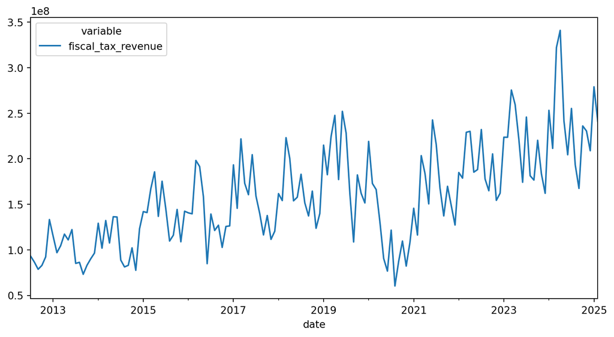

```python
import matplotlib as plt
df.plot()
```

# Appendix

## Camelot

Running camelot may need some additional Libraries

`conda install -c conda-forge cv2 --yes` `pip install opencv-contrib-python`